# M2_891_20251_PEC4_Enunciado

[figure not shown]

M2.891 · Aprendizaje automático · PEC4

2025-1· Máster universitario en Ciencia de datos (Data science)

Estudios de Informática, Multimedia y Telecomunicación

# **PEC 4: Combinación de Modelos**

## Objetivo

Esta cuarta Práctica de Evaluación Continua (PEC 4) tiene como objetivo principal consolidar los conocimientos adquiridos en las PECs anteriores (introducción al aprendizaje automático, análisis exploratorio de datos, métodos supervisados y no supervisados) e introducir y profundizar en técnicas avanzadas de Ensemble Learning (Aprendizaje por Conjuntos).

Al finalizar esta PEC, deberías ser capaz de:

- Implementar y comparar diversas técnicas de ensemble learning (p. ej., Bagging/Random Forest, Boosting -AdaBoost, Gradient Boosting-, Stacking y cascading) sobre un conjunto de datos específico.
- Analizar y explicar cómo los hiperparámetros clave de los métodos ensemble influyen en su comportamiento y rendimiento.
- Evaluar y comparar la importancia de las características (feature importance) obtenida a través de diferentes modelos ensemble.
- Justificar cuándo y por qué un método ensemble podría ser preferible a otro, o a un modelo individual (conectando con conceptos como el trade-off sesgo-varianza).
- Aplicar correctamente metodologías de validación (como validación cruzada) para la evaluación y comparación robusta de los modelos ensemble.

## Conjunto de datos

Una compañía opera un parque eólico crítico con 3000 turbinas y busca optimizar sus costes operativos y asegurar la continuidad del servicio.

Actualmente, la estrategia de mantenimiento es ineficiente: o bien es reactiva (arreglar cuando se rompe, lo cual es muy costoso) o preventivo-fija (revisar cada X meses, lo cual desperdicia recursos en máquinas sanas). Vuestro objetivo es desarrollar un modelo de Mantenimiento Predictivo basado en los datos de los sensores instalados en las turbinas.

El dataset (`wind_turbine_data.csv`) contiene lecturas de sensores de vibración, temperatura, eléctricos y ambientales. Los valores de los sensores ya han sido transformados por el equipo de ingeniería de datos. Se presentan como **z-scores (estandarizados)**. Esto significa que veréis valores positivos y negativos centrados en cero. Un valor de `0` indica que el sensor está en su media histórica operativa; valores altos (positivos o negativos) indican desviaciones anómalas respecto al comportamiento normal. Por ejemplo, una temperatura "negativa" no significa bajo cero absoluto, sino que es más baja que el promedio habitual de funcionamiento.

Las variables del dataset se agrupan por subsistemas de la turbina:

| Subsistema | Variables (Sensores) | Descripción |
| --- | --- | --- |
| **Target** | `Operational_Status` | Variable a predecir: **0: Normal** (Funcionamiento óptimo). **1: Warning** (Alerta de Mantenimiento. Requiere visita). **2: Failure** (Fallo Crítico. Parada inmediata necesaria). |
| **Generador** | `Gen_Avg_RPM` `Gen_Output_Voltage` `Gen_Coil_Temp` | Revoluciones por minuto, voltaje de salida y temperatura del bobinado. |
| **Red Eléctrica** | `Grid_Frequency_Hz` | Frecuencia de sincronización con la red eléctrica. |
| **Rotor y Palas** | `Rotor_Blade_Angle_1` `Rotor_Blade_Angle_2` `Rotor_Shaft_Vibration` `Rotor_Wind_Speed` | Ángulos de las palas, vibración del eje principal y velocidad del viento incidente. |
| **Hidráulica** | `Hydraulic_Oil_Pressure` `Hydraulic_Oil_Temp` `Hydraulic_Tank_Level` | Estado del sistema hidráulico (frenos y orientación). |
| **Caja de Cambios** | `Gearbox_Bearing_Temp` `Gearbox_Vibration_X` `Gearbox_Vibration_Y` | Temperatura de rodamientos y vibración en ejes X/Y. |
| **Ambiental** | `Amb_Ext_Temp` `Amb_Humidity` `Amb_Wind_Turbulence` `Tower_Oscillation` | Condiciones externas y oscilación de la torre. |
| **Metadatos** | `Installation_Region` `Turbine_Model` | Región geográfica y modelo de la máquina. |

El objetivo no es solo implementar los algoritmos, sino sobre todo analizar en profundidad su comportamiento, comparar sus resultados y justificar tus conclusiones basándote siempre en la evidencia obtenida de tus propios experimentos y resultados numéricos/gráficos. Se valorará especialmente la capacidad crítica y la profundidad de tus interpretaciones.

**Nombre y apellidos:** Jorge Solán Morote

## 1. Carga, Análisis Exploratorio Crítico y Limpieza de Datos (1 punto)

#### Implementación:

1. Carga el dataset `wind_turbine_data.csv`.
2. Análisis Exploratorio de Datos (EDA) Asistido por I.A.:
   - Utiliza una herramienta de I.A. Generativa (ej. ChatGPT, Gemini, Copilot, Calude, etc.) para asistirte en la realización de un EDA exhaustivo.
   - Revisa la información general del dataset (tipos de datos, variables categóricas/numéricas).
   - Analiza los valores atípicos, los patrones de correlación y la distribución de la variable objetivo (`Operational_Status`).
3. **Análisis Crítico:** Basándote únicamente en los hallazgos de tu EDA, discute los principales desafíos que anticipas que este dataset podría presentar para los modelos de clasificación estándar. Identifica las variables más importantes para la clasificación.
4. Preparación y Justificación de Datos:
   - Realiza las transformaciones de datos necesarias para la Clasificación.
   - Justifica tus decisiones sobre: Codificación de variables categóricas, Escalado/Normalización de variables numéricas, y manejo de variables con patrones de distribución no lineales (si decides transformarlas).
   - Recuerda aplicar la división correcta entre Train/Test sets y evitar la fuga de datos. Usa siempre com semilla el número 42.
5. **Análisis Crítico: Reflexión sobre el Uso de I.A. Generativa**
   - Se claro y honesto: ¿Qué herramienta de I.A. has usado y para qué tareas específicas?
   - Identifica las sugerencias erróneas o engañosa que la I.A. te haya dado durante el EDA o la preparación de datos. ¿Cómo las has corregido?
   - Concluye: ¿Cuál es el principal riesgo de delegar el análisis completamente a una I.A.?

```python
seed = 42
```

```python
import pandas as pd
import numpy as np
import matplotlib.pyplot as plt
import seaborn as sns

from sklearn.model_selection import train_test_split, GridSearchCV
from sklearn.preprocessing import RobustScaler
from sklearn.ensemble import RandomForestClassifier, GradientBoostingClassifier
from sklearn.linear_model import LogisticRegression
from sklearn.tree import DecisionTreeClassifier
from sklearn.neighbors import KNeighborsClassifier
from sklearn.naive_bayes import GaussianNB
from sklearn.metrics import classification_report, accuracy_score, f1_score,  recall_score
from sklearn.ensemble import StackingClassifier
from imblearn.ensemble import BalancedRandomForestClassifier
```

#### Solución:

### 1. Carga del dataset

```python
df = pd.read_csv("wind_turbine_data.csv")
```

### 2. EDA con IA

Para este apartado le he pasado a Claude, con el modelo Sonnet 4.5, las diferentes variables del dataset por subsistema del enunciado para darle contexto y le he pedido que me de ideas para realizar un EDA con los apartados de:

- Revisa la información general del dataset (tipos de datos, variables categóricas/numéricas).
- Analiza los valores atípicos, los patrones de correlación y la distribución de la variable objetivo (`Operational_Status`).

Tras esto he ido me ha dado una serie de ideas de apartados para incluir en el EDA.

1. REVISIÓN INICIAL DEL DATASET
2. ANÁLISIS DE LA VARIABLE OBJETIVO
3. ANÁLISIS DE VARIABLES CATEGÓRICAS
4. ESTADÍSTICAS DESCRIPTIVAS DE VARIABLES NUMÉRICAS
5. ANÁLISIS DE VALORES ATÍPICOS (OUTLIERS)
6. DISTRIBUCIONES DE VARIABLES NUMÉRICAS
7. MATRIZ DE CORRELACIÓN
8. ANÁLISIS POR SUBSISTEMAS
9. ANÁLISIS MULTIVARIADO POR ESTADO OPERACIONAL

Con esta información que me ha dado, así ha quedado el EDA de los datos.

```
REVISIÓN INICIAL DEL DATASET
Dimensiones: 3000 filas × 24 columnas

Primeras 5 filas:
  Installation_Region    Turbine_Model  Gen_Avg_RPM  Gen_Output_Voltage  \
0        South_Plains  Turbine_Model_C     1.821258            0.910395
1        South_Plains  Turbine_Model_B     4.229767           -0.434469
2      High_Mountains  Turbine_Model_D     0.860488            0.984565
3        South_Plains  Turbine_Model_D     1.503285            1.769841
4      High_Mountains  Turbine_Model_B    -0.019055           -1.569077

   Gen_Coil_Temp  Grid_Frequency_Hz  Rotor_Blade_Angle_1  Rotor_Blade_Angle_2  \
0       0.459186          -1.030711             2.098087             1.921148
1       4.726087           0.995552            -3.966756             2.444360
2       0.042947          -0.365520            -4.947303            -0.574780
3       1.307190           1.309311             1.169251             0.514564
4      -0.824806           2.347602            -1.001121             0.323452

   Rotor_Wind_Speed  Rotor_Shaft_Vibration  ...  Gearbox_Bearing_Temp  \
0         -1.737789              -2.657309  ...              1.897052
1          0.848826              -3.308983  ...             -5.080912
2          2.228463              -2.312484  ...             -5.960220
3          0.674670               0.847147  ...             -1.040373
4         -1.544061              -1.198919  ...              3.031140

   Gearbox_Vibration_X  Gearbox_Vibration_Y  Amb_Ext_Temp  Amb_Humidity  \
0            -1.394981             4.431102      0.699121     -1.445639
1            -1.526828             0.863514      0.032210     -0.047262
2            -2.220760            -3.323280     -1.348569      0.282364
3            -1.001201             3.293377      0.117673      1.102933
4             0.584622             4.140137     -0.174062      0.230008

   Amb_Wind_Turbulence  Tower_Oscillation  Tower_Fatigue_Index  \
0             2.348258           0.652387            -0.374180
1             0.193590           1.075823             0.181950
2             3.002487           0.343067            -0.461241
3             1.347602          -0.644789             1.442618
4             1.357896           1.410082            -0.555238

   System_Efficiency_Calc  Operational_Status
```

[output cut: 61 more lines]

```
Amb_Humidity                       0
Amb_Wind_Turbulence                0
Tower_Oscillation                  0
Tower_Fatigue_Index                0
System_Efficiency_Calc             0
Operational_Status                 0
dtype: int64

Total de valores nulos: 0
ANÁLISIS DE LA VARIABLE OBJETIVO

Distribución de clases:
  Clase 0 (Normal): 1,490 (49.67%)
  Clase 1 (Warning): 907 (30.23%)
  Clase 2 (Failure): 603 (20.10%)
```

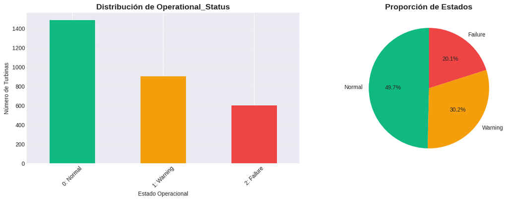

```
ANÁLISIS DE VARIABLES CATEGÓRICAS

 Installation_Region:
Installation_Region
South_Plains       750
High_Mountains     750
Interior_Valley    750
North_Coast        750
Name: count, dtype: int64
  Categorías únicas: 4

 Turbine_Model:
Turbine_Model
Turbine_Model_A    866
Turbine_Model_B    815
Turbine_Model_C    788
Turbine_Model_D    531
Name: count, dtype: int64
  Categorías únicas: 4

Relación de categóricas con Operational_Status:

Installation_Region:
Operational_Status       0      1      2
Installation_Region
High_Mountains       50.00  30.53  19.47
Interior_Valley      50.67  28.27  21.07
North_Coast          42.53  29.07  28.40
South_Plains         55.47  33.07  11.47

Turbine_Model:
Operational_Status      0      1      2
Turbine_Model
Turbine_Model_A     52.19  40.42   7.39
Turbine_Model_B     37.91  33.37  28.71
Turbine_Model_C     72.08  11.17  16.75
Turbine_Model_D     30.32  37.10  32.58
ESTADÍSTICAS DESCRIPTIVAS DE VARIABLES NUMÉRICAS

Variables numéricas identificadas: 21
```

[output cut: 74 more lines]

```

Resumen de outliers por variable:
                  Variable  Outliers Porcentaje        Min        Max
20  System_Efficiency_Calc       168      5.60%  -5.427674   6.772951
14     Gearbox_Vibration_Y        55      1.83% -12.132204  12.814550
3        Grid_Frequency_Hz        54      1.80%  -7.177407   7.803933
9   Hydraulic_Oil_Pressure        48      1.60%  -7.571720   7.543879
12    Gearbox_Bearing_Temp        47      1.57%  -8.197277  10.572708
11    Hydraulic_Tank_Level        46      1.53%  -8.583947   6.208537
17     Amb_Wind_Turbulence        42      1.40%  -9.801035   7.863993
1       Gen_Output_Voltage        30      1.00%  -7.017886   7.291045
19     Tower_Fatigue_Index        29      0.97%  -3.587773   3.856838
5      Rotor_Blade_Angle_2        29      0.97%  -3.596199   4.199419

 Visualización de outliers (Top 8 variables):
```

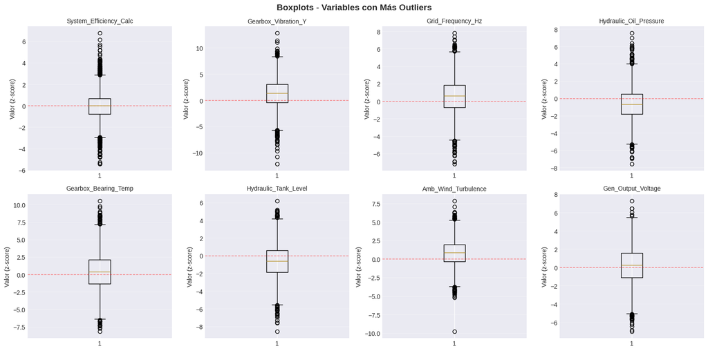

```
DISTRIBUCIONES DE VARIABLES NUMÉRICAS

 Histogramas de distribución (primeras 12 variables):
```

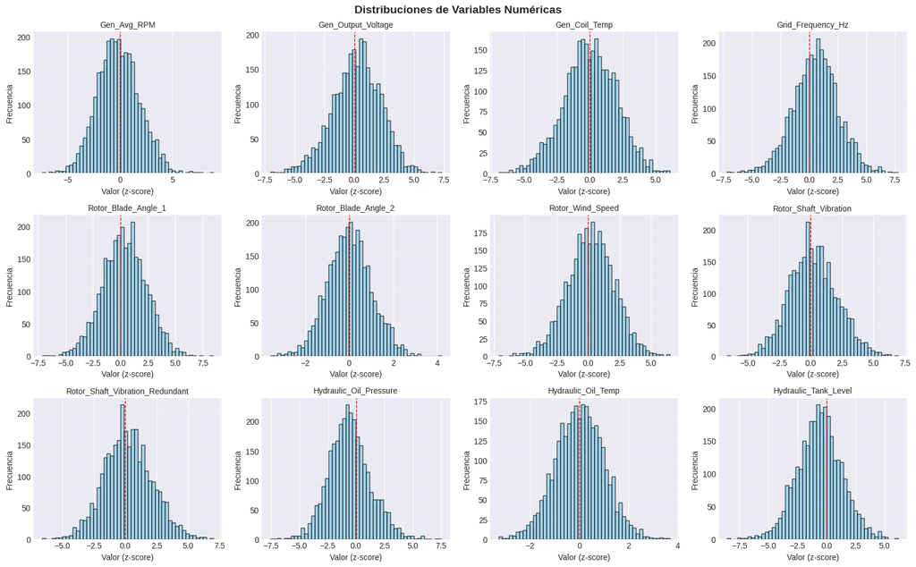

```
MATRIZ DE CORRELACIÓN

 Top 15 correlaciones más fuertes:
                Variable 1                       Variable 2  Correlación
119  Rotor_Shaft_Vibration  Rotor_Shaft_Vibration_Redundant     1.000000
68       Grid_Frequency_Hz                     Amb_Ext_Temp    -0.608395
48           Gen_Coil_Temp             Gearbox_Bearing_Temp    -0.542683
14             Gen_Avg_RPM                     Amb_Ext_Temp     0.532893
175   Gearbox_Bearing_Temp              Gearbox_Vibration_Y     0.532709
83     Rotor_Blade_Angle_1              Gearbox_Vibration_Y     0.491075
81     Rotor_Blade_Angle_1             Gearbox_Bearing_Temp     0.476059
33      Gen_Output_Voltage                     Amb_Ext_Temp    -0.455625
65       Grid_Frequency_Hz             Gearbox_Bearing_Temp     0.438572
112       Rotor_Wind_Speed              Gearbox_Vibration_Y    -0.433181
110       Rotor_Wind_Speed             Gearbox_Bearing_Temp    -0.405193
67       Grid_Frequency_Hz              Gearbox_Vibration_Y     0.402830
176   Gearbox_Bearing_Temp                     Amb_Ext_Temp    -0.389892
51           Gen_Coil_Temp                     Amb_Ext_Temp     0.378670
113       Rotor_Wind_Speed                     Amb_Ext_Temp    -0.358116
```

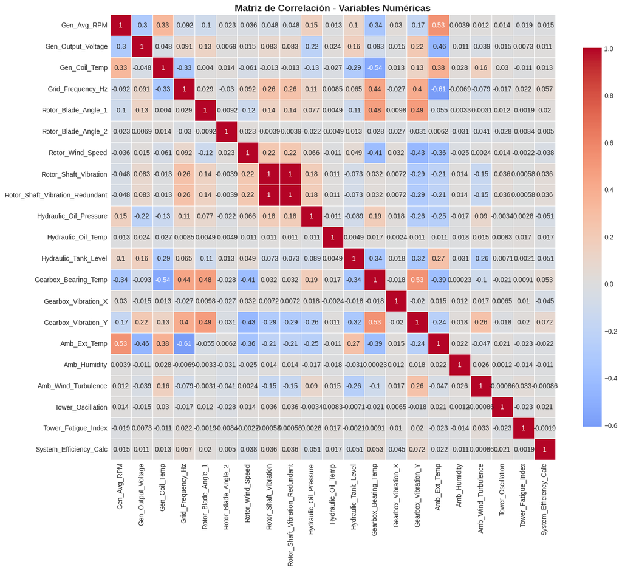

```
ANÁLISIS POR SUBSISTEMAS

 Generador:
       Gen_Avg_RPM  Gen_Output_Voltage  Gen_Coil_Temp
count     3000.000            3000.000       3000.000
mean        -0.168               0.194          0.022
std          1.993               2.010          1.989
min         -7.430              -7.018         -6.903
25%         -1.538              -1.085         -1.288
50%         -0.234               0.260          0.042
75%          1.122               1.573          1.420
max          8.854               7.291          6.099

 Red Eléctrica:
       Grid_Frequency_Hz
count           3000.000
mean               0.565
std                1.998
min               -7.177
25%               -0.698
50%                0.617
75%                1.849
max                7.804

 Rotor:
       Rotor_Blade_Angle_1  Rotor_Blade_Angle_2  Rotor_Shaft_Vibration  \
count             3000.000             3000.000               3000.000
mean                 0.339                0.002                  0.215
std                  1.989                1.005                  1.905
min                 -7.157               -3.596                 -6.641
25%                 -1.032               -0.668                 -1.107
50%                  0.317               -0.006                  0.130
75%                  1.672                0.654                  1.447
max                  8.440                4.199                  6.973

       Rotor_Wind_Speed
count          3000.000
mean              0.201
std               1.857
min              -7.128
```

[output cut: 54 more lines]

```
0                                 0.032            -0.024
1                                -0.005             0.744
2                                -0.064            -0.060

                    Rotor_Shaft_Vibration  Rotor_Shaft_Vibration_Redundant  \
Operational_Status
0                                  -0.011                           -0.011
1                                   0.811                            0.811
2                                  -0.122                           -0.122

                    Hydraulic_Oil_Pressure
Operational_Status
0                                   -0.808
1                                   -0.071
2                                   -0.753
```

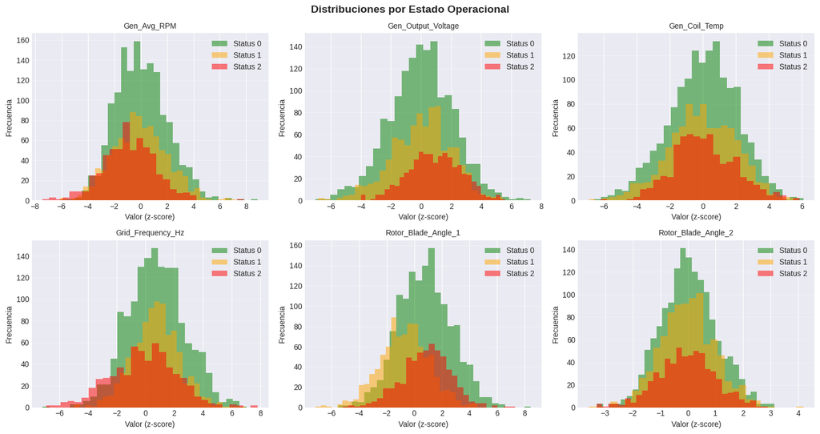

```python
# Configuración de visualización
plt.style.use('seaborn-v0_8-darkgrid')
sns.set_palette("husl")
plt.rcParams['figure.figsize'] = (15, 6)

# 1. REVISIÓN INICIAL DEL DATASET
print("\nREVISIÓN INICIAL DEL DATASET")
print(f"Dimensiones: {df.shape[0]} filas × {df.shape[1]} columnas")
print(f"\nPrimeras 5 filas:")
print(df.head())

print("\nInformación de tipos de datos:")
print(df.info())

print("\nResumen de valores nulos:")
print(df.isnull().sum())
print(f"\nTotal de valores nulos: {df.isnull().sum().sum()}")


# 2. ANÁLISIS DE LA VARIABLE OBJETIVO
print("ANÁLISIS DE LA VARIABLE OBJETIVO")

status_counts = df['Operational_Status'].value_counts().sort_index()
status_pct = df['Operational_Status'].value_counts(normalize=True).sort_index() * 100

print("\nDistribución de clases:")
for idx, (count, pct) in enumerate(zip(status_counts, status_pct)):
    labels = ['Normal', 'Warning', 'Failure']
    print(f"  Clase {idx} ({labels[idx]}): {count:,} ({pct:.2f}%)")

# Visualización
fig, axes = plt.subplots(1, 2, figsize=(14, 5))

# Gráfico de barras
status_counts.plot(kind='bar', ax=axes[0], color=['#10b981', '#f59e0b', '#ef4444'])
axes[0].set_title('Distribución de Operational_Status', fontsize=14, fontweight='bold')
axes[0].set_xlabel('Estado Operacional')
axes[0].set_ylabel('Número de Turbinas')
axes[0].set_xticklabels(['0: Normal', '1: Warning', '2: Failure'], rotation=45)
axes[0].grid(axis='y', alpha=0.3)

# Gráfico de pastel
axes[1].pie(status_counts, labels=['Normal', 'Warning', 'Failure'],
            autopct='%1.1f%%', startangle=90, colors=['#10b981', '#f59e0b', '#ef4444'])
axes[1].set_title('Proporción de Estados', fontsize=14, fontweight='bold')

plt.tight_layout()
plt.show()


# 3. ANÁLISIS DE VARIABLES CATEGÓRICAS
print("ANÁLISIS DE VARIABLES CATEGÓRICAS")

categorical_cols = ['Installation_Region', 'Turbine_Model']

for col in categorical_cols:
    print(f"\n {col}:")
    print(df[col].value_counts())
    print(f"  Categorías únicas: {df[col].nunique()}")

# Relación con variable objetivo
print("\nRelación de categóricas con Operational_Status:")
for col in categorical_cols:
    print(f"\n{col}:")
    cross_tab = pd.crosstab(df[col], df['Operational_Status'], normalize='index') * 100
    print(cross_tab.round(2))


# 4. ESTADÍSTICAS DESCRIPTIVAS DE VARIABLES NUMÉRICAS
print("ESTADÍSTICAS DESCRIPTIVAS DE VARIABLES NUMÉRICAS")

# Identificar variables numéricas
numeric_cols = df.select_dtypes(include=[np.number]).columns.tolist()
if 'Operational_Status' in numeric_cols:
    numeric_cols.remove('Operational_Status')

print(f"\nVariables numéricas identificadas: {len(numeric_cols)}")
print("\n Estadísticas descriptivas:")
print(df[numeric_cols].describe().round(3))


# 5. ANÁLISIS DE VALORES ATÍPICOS (OUTLIERS)

print("ANÁLISIS DE VALORES ATÍPICOS (OUTLIERS)")

outliers_summary = []

for col in numeric_cols:
    Q1 = df[col].quantile(0.25)
    Q3 = df[col].quantile(0.75)
    IQR = Q3 - Q1
    lower_bound = Q1 - 1.5 * IQR
    upper_bound = Q3 + 1.5 * IQR

    outliers = df[(df[col] < lower_bound) | (df[col] > upper_bound)]
    outliers_pct = (len(outliers) / len(df)) * 100

    outliers_summary.append({
        'Variable': col,
        'Outliers': len(outliers),
        'Porcentaje': f'{outliers_pct:.2f}%',
        'Min': df[col].min(),
        'Max': df[col].max()
    })

outliers_df = pd.DataFrame(outliers_summary).sort_values('Outliers', ascending=False)
print("\nResumen de outliers por variable:")
print(outliers_df.head(10))

# Para mirar mejor el tema de los outliers podemos crear boxplots de alguna de ellas
print("\n Visualización de outliers (Top 8 variables):")
top_outlier_cols = outliers_df.head(8)['Variable'].tolist()

fig, axes = plt.subplots(2, 4, figsize=(16, 8))
axes = axes.ravel()

for idx, col in enumerate(top_outlier_cols):
    axes[idx].boxplot(df[col], vert=True)
    axes[idx].set_title(col, fontsize=10)
    axes[idx].set_ylabel('Valor (z-score)')
    axes[idx].grid(axis='y', alpha=0.3)
    axes[idx].axhline(y=0, color='red', linestyle='--', linewidth=1, alpha=0.5)

plt.suptitle('Boxplots - Variables con Más Outliers', fontsize=14, fontweight='bold')
plt.tight_layout()
plt.show()


# 6. DISTRIBUCIONES DE VARIABLES NUMÉRICAS
print("DISTRIBUCIONES DE VARIABLES NUMÉRICAS")


# Visualización de distribuciones
print("\n Histogramas de distribución (primeras 12 variables):")
fig, axes = plt.subplots(3, 4, figsize=(16, 10))
axes = axes.ravel()

for idx, col in enumerate(numeric_cols[:12]):
    axes[idx].hist(df[col].dropna(), bins=50, color='skyblue', edgecolor='black', alpha=0.7)
    axes[idx].set_title(col, fontsize=10)
    axes[idx].set_xlabel('Valor (z-score)')
    axes[idx].set_ylabel('Frecuencia')
    axes[idx].axvline(x=0, color='red', linestyle='--', linewidth=1)
    axes[idx].grid(axis='y', alpha=0.3)

plt.suptitle('Distribuciones de Variables Numéricas', fontsize=14, fontweight='bold')
plt.tight_layout()
plt.show()


# 7. MATRIZ DE CORRELACIÓN
print("MATRIZ DE CORRELACIÓN")

# Calcular matriz de correlación
correlation_matrix = df[numeric_cols].corr()

# Correlaciones más fuertes
print("\n Top 15 correlaciones más fuertes:")
corr_pairs = []
for i in range(len(correlation_matrix.columns)):
    for j in range(i+1, len(correlation_matrix.columns)):
        corr_pairs.append({
            'Variable 1': correlation_matrix.columns[i],
            'Variable 2': correlation_matrix.columns[j],
            'Correlación': correlation_matrix.iloc[i, j]
        })

corr_df = pd.DataFrame(corr_pairs).sort_values('Correlación', key=abs, ascending=False)
print(corr_df.head(15))

# Visualización de matriz de correlación
plt.figure(figsize=(14, 12))
sns.heatmap(correlation_matrix, annot=True, cmap='coolwarm', center=0,
            square=True, linewidths=0.5, cbar_kws={"shrink": 0.8})
plt.title('Matriz de Correlación - Variables Numéricas', fontsize=14, fontweight='bold')
plt.tight_layout()
plt.show()


# 8. ANÁLISIS POR SUBSISTEMAS
print("ANÁLISIS POR SUBSISTEMAS")

subsystems = {
    'Generador': ['Gen_Avg_RPM', 'Gen_Output_Voltage', 'Gen_Coil_Temp'],
    'Red Eléctrica': ['Grid_Frequency_Hz'],
    'Rotor': ['Rotor_Blade_Angle_1', 'Rotor_Blade_Angle_2', 'Rotor_Shaft_Vibration', 'Rotor_Wind_Speed'],
    'Hidráulica': ['Hydraulic_Oil_Pressure', 'Hydraulic_Oil_Temp', 'Hydraulic_Tank_Level'],
    'Caja de Cambios': ['Gearbox_Bearing_Temp', 'Gearbox_Vibration_X', 'Gearbox_Vibration_Y'],
    'Ambiental': ['Amb_Ext_Temp', 'Amb_Humidity', 'Amb_Wind_Turbulence', 'Tower_Oscillation']
}

for subsystem, vars in subsystems.items():
    available_vars = [v for v in vars if v in df.columns]
    if available_vars:
        print(f"\n {subsystem}:")
        print(df[available_vars].describe().round(3))


# 9. ANÁLISIS MULTIVARIADO POR ESTADO OPERACIONAL
print(" ANÁLISIS COMPARATIVO POR ESTADO OPERACIONAL")

# Estadísticas por estado
print("\n Medias por Estado Operacional (primeras 10 variables):")
status_means = df.groupby('Operational_Status')[numeric_cols[:10]].mean()
print(status_means.round(3))

# Visualización comparativa
fig, axes = plt.subplots(2, 3, figsize=(15, 8))
axes = axes.ravel()

sample_vars = numeric_cols[:6]
for idx, col in enumerate(sample_vars):
    for status in [0, 1, 2]:
        data = df[df['Operational_Status'] == status][col].dropna()
        axes[idx].hist(data, bins=30, alpha=0.5,
                      label=f'Status {status}',
                      color=['green', 'orange', 'red'][status])

    axes[idx].set_title(col, fontsize=10)
    axes[idx].set_xlabel('Valor (z-score)')
    axes[idx].set_ylabel('Frecuencia')
    axes[idx].legend()
    axes[idx].grid(axis='y', alpha=0.3)

plt.suptitle('Distribuciones por Estado Operacional', fontsize=14, fontweight='bold')
plt.tight_layout()
plt.show()
```

#### Análisis:

**USA TANTAS CELDAS COMO NECESITES**

### 3. Análisis Crítico

El **primero** de los desafíos del dataset es el desbalance de la variable objetivo `Operational_Status` como podemos ver en la siguiente tabla:

| Valor | Porcentaje | Muestras |
| --- | --- | --- |
| Normal | 49.67% | 1490 turbinas |
| Warning | 30.23% | 907 turbinas |
| Failure | 20.10% | 603 turbinas |

Ratio: 2.47:1.50:1

Esto puede desencadenar en un sesgo hacia la clase mayoritaria, para maximizar el Accuracy.  
La clase más problemática es la que menos muestras tiene, con que un mal modelo puede no hacerle el suficiente caso a esas muestras.

El **segundo** de los problemas es la correlación de alguna de las vaiables. Si vemos la matriz de correlación hay un caso en particular con una puntuación de 1.0, el caso de la variable Rotor_Shaft_Vibration con Rotor_Shaft_Vibration_Redundant, con lo que, para el modelo, con una de ambas variables es más que suficiente ya que representan lo mismo. Además de esto, hay algunas variables con una correlación más alta de 0.5 que genera multicolinealidad:

| Variable 1 | Variable 2 | Correlación |
| --- | --- | --- |
| Grid_Frequency_Hz | Amb_Ext_Temp: | -0.608 |
| Gen_Coil_Temp | Gearbox_Bearing_Temp: | -0.543 |
| Gen_Avg_RPM | Amb_Ext_Temp: | 0.533 |
| Gearbox_Bearing_Temp | Gearbox_Vibration_Y: | 0.533 |

El **tercer** problema son los outliers. Para mirarlos, simplemente he tomado en el EDA como outliers los que se salen de los cuantiles 1 y 3, fuera del boxplot. Sin embargo, viendo el resto de análisis creo que no hay que eliminarlos directamente, si los vemos detenidamente en la variable `System_Efficiency_Calc` hay un 5.6% de outliers, unas 168 turbinas, pero en un dataset de este estilo, que se tienen datos del mantenimiento de las turbinas justamente estos outliers pueden significar fallos o advertencias, los necesarios para hacer una correcta predicción en el modelo. Por lo cual hay que diferenciar bien, outliers y valores críticos que indiquen fallos.

De las variables importantes para la clasificación, en su mayoria de veces, cuantas más mejor, pero vamos a quedarnos con las 5 que creo que tienen características diferenciadoras que nos ayudan a reducir el número de datos a tratar.

[output not shown]

[output not shown]

1. Gen_Avg_RPM: Viendo su media según el tipo de gravedad encontramos que, cuando tiene un fallo su valor suele bajar hasta -0.85 de media, con lo cual, valores negativos cercanos a 1 en esta variable puede indicar un fallo.
2. Gen_Output_Voltage: Algo parecido sucede con esta variable, cuando hay un fallo, la media de esta variable suele tener valores positivos en este caso, cercanos a 0.9
3. Rotor_Blade_Angle_1: En cambio nos puede ayudar a detectar peligro, de media, esta variable en warning tiene valores cercanos a 0.7 negativos, mientras que con fallo o normales suele estar con valores positivos cercanos a 0.8
4. Rotor_Shaft_Vibration: Es otra variable que nos puede ayudar a diferenciar si la turbina está en warning ya que suele tener valores positivos cercanos a 0.8 en estos casos y valores cercanos a -0.1 en los otros dos casos.
5. Turbine_model: Con esta variable categórica podemos ver diferentes casos. El modelo C suele ser el que se mantiene más en estado "normal", en cambio el B y sobre todo el D suelen tener bastantes más fallos que los otros.

### 4. Preparación y Justificación

Transformaciones de datos previas:

- Eliminar una variable de carrelación 1.0 Las variables Rotor_Shaft_Vibration_Redundant y Rotor_Shaft_Vibration tienen una correlación perfecta con que lo mejor para el modelo es eliminar una de estas dos columnas y no ensuciar el modelo.
- Variables categóricas con ONE-HOT encoding. Ya que no hay un orden en las variables categóricas, un label encoding pondria las variables como 0, 1, 2 y 3 pero esto sí crearía un orden entre estas creando un sesgo inexistente, por ello y ya que son pocas categorías, con one-hot enconding podemos tener nuevas variables que nos indiquen si una turbina pertenece o no a una de estas categorías sin tener relación entre ellas.
- Sobre los outliers, como ya hemos visto antes lo mejor, a priori, es no hacer nada, no los eliminamos ni tratamos ya que lo más seguro es que estos outliers sean los datos que más fallos o warnings nos darán y nos ayuden con el modelo.
- En cuanto a escalar los datos hay que tener cuidado. Ya que hemos mantenido los outliers no es remoendable un StandardScaler porque es muy sensible a los outliers y hemos decidido mantenerlos, por ello el RobustScaler es mejor en este caso, ya que, para escalar, utiliza tanto la mediana como el IQR de los datos.

Por último, además de separar en test y entrenamiento simplemente decido además separar otro subconjunto de validación ya que apartados posteriores requieren este subconjunto.

```python
# Eliminamos Rotor_Shaft_Vibration_Redundant
redundant_cols = ['Rotor_Shaft_Vibration_Redundant']

df_clean = df.drop(columns=redundant_cols)

# Separar variable objetivo
y = df_clean['Operational_Status']
X = df_clean.drop('Operational_Status', axis=1)

# Primera división de los datos: Train (70%) vs Test+Val (30%)
X_train, X_temp, y_train, y_temp = train_test_split(
    X, y,
    test_size=0.30,      # 30% restante
    random_state=seed,
    stratify=y,
    shuffle=True
)

# Segunda división: Test (15% del total) y Val (15% del total)
X_val, X_test, y_val, y_test = train_test_split(
    X_temp, y_temp,
    test_size=0.50,      # mitad test, mitad val
    random_state=seed,
    stratify=y_temp,
    shuffle=True
)

# Identificar columnas categóricas y numéricas
categorical_cols = X_train.select_dtypes(include=['object']).columns.tolist()
numerical_cols = X_train.select_dtypes(include=[np.number]).columns.tolist()

# Aplicar One-Hot Encoding
X_train_encoded = pd.get_dummies(X_train, columns=categorical_cols, drop_first=False)
X_val_encoded = pd.get_dummies(X_val, columns=categorical_cols, drop_first=False)
X_test_encoded = pd.get_dummies(X_test, columns=categorical_cols, drop_first=False)

_, X_val_encoded = X_train_encoded.align(X_val_encoded, join='left', axis=1, fill_value=0)
_, X_test_encoded = X_train_encoded.align(X_test_encoded, join='left', axis=1, fill_value=0)


# Escalado con RobustScaler
# Actualizar lista de columnas numéricas (ahora con one-hot encoding)
numerical_cols_final = [col for col in X_train_encoded.columns if col in numerical_cols]

scaler = RobustScaler()
scaler.fit(X_train_encoded[numerical_cols_final])

# Aplicar transformación
X_train_scaled = X_train_encoded.copy()
X_val_scaled = X_val_encoded.copy()
X_test_scaled = X_test_encoded.copy()

X_train_scaled[numerical_cols_final] = scaler.transform(X_train_encoded[numerical_cols_final])
X_val_scaled[numerical_cols_final] = scaler.transform(X_val_encoded[numerical_cols_final])
X_test_scaled[numerical_cols_final] = scaler.transform(X_test_encoded[numerical_cols_final])
```

### 5. Análisis sobre el uso de IA.

En mi caso he utilizado Claude con el modelo Sonnet 4.5 para que me diga una lista de pasos a realizar en el análisis de este conjunto de datos. Para darle un poco más de contexto le he pasado el aparttado de "Conjunto de Datos" del enunciado, así al menos sabe sobre lo que estamos trabajando. Tras esto, me ha dado la lista de apartados del punto 1 y me ha preguntado si quería que los implementase, pero no he continuado más con la conversación.

En el apartado de la transformación de datos le he pasado algunos de los resultados del análisis y le he preguntado qué acciones me recomienda hacer. Sin embargo aquí no ha tenido en cuenta el tema de los outliers que he comentado en el análisis crítico, tras ponerle mejor en contexto ha terminado dándome la razón.

Si hubiera dejado todo el EDA a una IA, mi ejemplo con Claude mismo y no le hubiera puesto mucho en contexto de los datos, este hubiera realizado un análsis muy general, en este caso al menos me ha sugerido bastantes apartados buenos que he ido siguiendo para el EDA completo. Si en cambio le hubiera pasado también la tarea de preparación de los datos hubiera sido un grave problema, aunque le hubiera pasado todos los datos del análisis hubiera cometido fallos sin el contexto adecuado, es arriesgado encomendarles todo el trabajo a las IAs generativas, aunque hoy en día están bastante avanzadas, sin el contexto suficiente puede generar muchos fallos que se hubieran podido evitar fácilmente

## 2. Entrenamiento y Evaluación de Modelos Base (1 punto)

#### Implementación:

1. Entrena con el conjunto de datos de entrenamiento y valida con el conjunto de datos de validación los siguientes modelos base (Guarda las predicciones para su uso más adelante):
   - Regresión Logística (`LogisticRegression`)
   - Árbol de Decisión (`DecisionTreeClassifier`)
   - K vecinos cercanos (`KNeighborsClassifier`)
   - Clasificador Naïves-Bayes (`GaussianNB`)
2. Para cada modelo, reporta las métricas obtenidas de la validación que consideres necesarias.
3. **Análisis Crítico:** Comenta brevemente el rendimiento de modelos base. ¿Cuál de las métricas consideras más informativa para evaluar el rendimiento y por qué? Justifica tu respuesta.

#### Solución:

```python
# Definir los modelos en un diccionario para iterar fácilmente
models = {
    #https://scikit-learn.org/stable/modules/generated/sklearn.linear_model.LogisticRegression.html
    "Logistic Regression": LogisticRegression(
        random_state=seed,
        max_iter=1000,
        solver='lbfgs',
        class_weight='balanced'
    ),
    #https://scikit-learn.org/stable/modules/generated/sklearn.tree.DecisionTreeClassifier.html
    "Decision Tree": DecisionTreeClassifier(
        random_state=seed,
        class_weight='balanced',
        max_depth=10
    ),
    #https://scikit-learn.org/stable/modules/generated/sklearn.neighbors.KNeighborsClassifier.html
    "KNN": KNeighborsClassifier(
        n_neighbors=3,
        weights='distance'
    ),
    #https://scikit-learn.org/stable/modules/generated/sklearn.naive_bayes.GaussianNB.html
    "Naive Bayes": GaussianNB()
}

# Diccionarios para guardar resultados y predicciones futuras
results = {}
y_preds_val = {}

for name, model in models.items():
    model.fit(X_train_scaled, y_train)

    y_pred_val = model.predict(X_val_scaled)
    y_preds_val[name] = y_pred_val

    acc = accuracy_score(y_val, y_pred_val)
    f1 = f1_score(y_val, y_pred_val, average='macro')
    recall = recall_score(y_val, y_pred_val, average='macro')

    # Guardamos para el reporte final
    results[name] = {
        "Accuracy": acc,
        "F1-Score (Macro)": f1,
        "Recall (Macro)": recall
    }
```

```python
results_df = pd.DataFrame(results).T.sort_values(by="F1-Score (Macro)", ascending=False)
display(results_df)

# Ver el detalle numérico de cada clase para cada modelo
for model in results_df.index:
    print(f"\n--- Detalle del modelo: {model} ---")
    print(classification_report(y_val, y_preds_val[model],
                                target_names=['Normal', 'Warning', 'Failure']))
```

|  | Accuracy | F1-Score (Macro) | Recall (Macro) |
| --- | --- | --- | --- |
| KNN | 0.766667 | 0.724081 | 0.710288 |
| Decision Tree | 0.662222 | 0.636403 | 0.643292 |
| Naive Bayes | 0.657778 | 0.626349 | 0.633097 |
| Logistic Regression | 0.606667 | 0.591574 | 0.615485 |

```
--- Detalle del modelo: KNN ---
              precision    recall  f1-score   support

      Normal       0.78      0.88      0.83       223
     Warning       0.73      0.78      0.75       136
     Failure       0.78      0.47      0.59        91

    accuracy                           0.77       450
   macro avg       0.77      0.71      0.72       450
weighted avg       0.77      0.77      0.76       450


--- Detalle del modelo: Decision Tree ---
              precision    recall  f1-score   support

      Normal       0.76      0.70      0.73       223
     Warning       0.68      0.65      0.67       136
     Failure       0.46      0.57      0.51        91

    accuracy                           0.66       450
   macro avg       0.63      0.64      0.64       450
weighted avg       0.68      0.66      0.67       450


--- Detalle del modelo: Naive Bayes ---
              precision    recall  f1-score   support

      Normal       0.78      0.72      0.75       223
     Warning       0.66      0.63      0.64       136
     Failure       0.43      0.55      0.49        91

    accuracy                           0.66       450
   macro avg       0.63      0.63      0.63       450
weighted avg       0.67      0.66      0.66       450


--- Detalle del modelo: Logistic Regression ---
              precision    recall  f1-score   support

      Normal       0.79      0.55      0.65       223
     Warning       0.56      0.73      0.63       136
     Failure       0.43      0.57      0.49        91

    accuracy                           0.61       450
   macro avg       0.60      0.62      0.59       450
weighted avg       0.65      0.61      0.61       450
```

### Análisis Crítico.

Teniendo en cuenta que trabajamos como un predictor de fallos en turbinas eólicas lo mejor sería saber siempre lo que va a pasar, pero al ser esto muy poco posible lo mejor sería ponerse ante un modelo "catastrófico".

Esto significa intentar minimizar el número de falsos negativos, estos son turbinas en fallo real que nuestro modelo no ha predicho. Para ello lo mejor es maximizar el recall de la clase de fallo crítico(2).

Sin embargo, esta es la mejor métrica para optimizar, la métrica más informativa, en este caso y en el de muchos es el f1_macro, ya que esta, al contrario de la anterior nos aporta una mejor visión gloabl del rendimiento del modelo. Es verdad que debemos minimizar el recall 2, pero si en un punto, ese coste de reparación no fuera tan crítico el modelo no sería tan bueno como antes.

## 3. Combinación paralela de clasificadores de base similar: Bagging (1.5 puntos)

#### Implementación:

1. Implementa `RandomForestClassifier`.
2. Realiza una búsqueda y ajuste (tuning) de hiperparámetros clave (n_estimators, max_depth, max_features) utilizando validación cruzada (ej., GridSearchCV o RandomizedSearchCV con 5-CV). Define un rango de búsqueda razonable para cada hiperparámetro y usa la métrica que justificaste como más informativa en el punto anterior para la optimización.
3. Reporta los mejores hiperparámetros encontrados y el score de validación cruzada obtenido con ellos.

#### Solución:

```python
# Definir el grid de hiperparámetros
param_grid = {
    'n_estimators': [50, 100, 150],
    'max_depth': [10, 20, 30],
    'max_features': ['sqrt', 'log2'],
    'min_samples_split': [2, 5, 10],
    'min_samples_leaf': [1, 2, 4],
    'class_weight': ['balanced', 'balanced_subsample']
}

# Crear el modelo
rf = RandomForestClassifier(random_state=seed, n_jobs=-1)

# GridSearchCV con validación cruzada de 5 folds
grid_rf = GridSearchCV(
    estimator=rf,
    param_grid=param_grid,
    cv=5,
    scoring='f1_macro',
    n_jobs=-1,
    verbose=1,
    return_train_score=True
)

grid_rf.fit(X_train_scaled, y_train)

print("\nMEJORES HIPERPARÁMETROS")

for param, value in grid_rf.best_params_.items():
    print(f"  {param}: {value}")

print(f"\nMejor score de validación cruzada: {grid_rf.best_score_:.4f}")
```

```
Fitting 5 folds for each of 324 candidates, totalling 1620 fits
```

```
MEJORES HIPERPARÁMETROS
  class_weight: balanced_subsample
  max_depth: 20
  max_features: sqrt
  min_samples_leaf: 4
  min_samples_split: 2
  n_estimators: 150

Mejor score de validación cruzada: 0.7406
```

#### Análisis:

**USA TANTAS CELDAS COMO NECESITES**

#### Implementación:

4. Valida (con el conjunto de datos de validación) el modelo Random Forest final (entrenado con los mejores hiperparámetros sobre todo el set de entrenamiento).
5. Muestra un gráfico de la importancia de las características (feature_importance_) del modelo final
6. **Análisis Crítico:** Compara el rendimiento de tu Random Forest optimizado con los modelos base (refiérete a los valores específicos de las métricas que obtuviste). ¿Logró RF una mejora sustancial, especialmente en las clases minoritarias? Analiza tu gráfico de importancia de características: ¿Qué variables parecen ser las más relevantes según RF? ¿Tiene sentido este resultado? ¿Identifica RF algunas de las variables categóricas que se habían identificado como importantes?

#### Solución:

```
EVALUACIÓN EN CONJUNTO DE VALIDACIÓN
              precision    recall  f1-score   support

      Normal       0.82      0.86      0.84       223
     Warning       0.73      0.79      0.76       136
     Failure       0.74      0.57      0.65        91

    accuracy                           0.78       450
   macro avg       0.77      0.74      0.75       450
weighted avg       0.78      0.78      0.78       450

IMPORTANCIA DE CARACTERÍSTICAS
                      feature  importance
          Rotor_Blade_Angle_1    0.086485
          Gearbox_Vibration_Y    0.080489
            Grid_Frequency_Hz    0.066565
           Gen_Output_Voltage    0.064670
       Hydraulic_Oil_Pressure    0.063641
         Gearbox_Bearing_Temp    0.057510
             Rotor_Wind_Speed    0.055839
                  Gen_Avg_RPM    0.054616
        Rotor_Shaft_Vibration    0.053836
         Hydraulic_Tank_Level    0.046505
          Amb_Wind_Turbulence    0.046028
                Gen_Coil_Temp    0.042859
                 Amb_Ext_Temp    0.036109
Turbine_Model_Turbine_Model_A    0.029251
Turbine_Model_Turbine_Model_C    0.028403
```

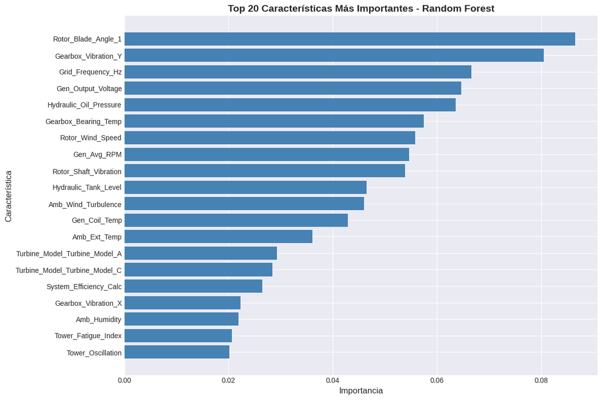

```python
# Evaluar el mejor modelo en el conjunto de prueba
best_rf = grid_rf.best_estimator_
y_pred_best = best_rf.predict(X_val_scaled)

print("EVALUACIÓN EN CONJUNTO DE VALIDACIÓN")
print(classification_report(y_val, y_pred_best, target_names=['Normal', 'Warning', 'Failure']))


print("IMPORTANCIA DE CARACTERÍSTICAS")
# Obtener importancia de características
feature_importance = pd.DataFrame({
    'feature': X_train_scaled.columns,
    'importance': best_rf.feature_importances_
}).sort_values('importance', ascending=False)
print(feature_importance.head(15).to_string(index=False))

# Gráfico de importancia de características
plt.figure(figsize=(12, 8))
top_features = feature_importance.head(20)
plt.barh(range(len(top_features)), top_features['importance'], color='steelblue')
plt.yticks(range(len(top_features)), top_features['feature'])
plt.xlabel('Importancia', fontsize=12)
plt.ylabel('Característica', fontsize=12)
plt.title('Top 20 Características Más Importantes - Random Forest', fontsize=14, fontweight='bold')
plt.gca().invert_yaxis()
plt.tight_layout()
plt.show()
```

#### Análisis:

**USA TANTAS CELDAS COMO NECESITES**

### Análisis crítico

Sí, podemos observar una mejora sustancial, no solo en las clases minoritarias sino también en la mayoría de casos de la clase mayoritaria. Tiene la precisión más alta en la clase Normal con 82%, la más alta, empatada con KNN, en la clase Warning con 73% y la segunda precisión más alta, detrás de KNN en la clase de Failure con 74%. En recall vemos algo similar, el segundo recall más alto, solo detrás de KNN y las otras clases con un recall superior o igual al resto. Mirando la métrica más informativa del modelo, el f1_score, tanto en macro, la media, como en el weighted, la media teniendo en cuenta el número de datos de cada clase, en ambas gana al resto de modelos, poniendolo, de momento, como el mejor de todos.

Mirando algunas de las variables más importantes por el modelo encontramos:

- Rotor_Blade_Angle_1: El ángulo de las palas de la turbina eólica, por lo general estas deberían estar siempre con el mismo ángulo, una desviación en esto podría ser fatal, tanto para el motor a futuro como para el funcionamiento actual.
- Gearbox_Vibration_Y: La vibración en la caja de cambios, una desviación en este valor, o si es menor, puede significar que funciona por debajo de lo normal o si es mayor puede significar que alguna de las piezas de la caja de cambios está defectuosa.
- Grid_Frequency_Hz: La sincronización con la red electrica también es un punto de fallo ya que puede llevar fácilmente a un mal abastecimiento de la red.
- Gen_Output_Voltage: El voltaje del generador. Un voltaje por encima de la media puede significar un mal funcionamiento de alguna parte del sistema en general y si genera menos también puede significar algo parecido.

Con lo cual si, tienen sentido las variables que nos dice el RF.

Por último, entre las 20 estadísticas que he sacado identifica como relevante la variable categórica del modelo de la turbina, en este caso el A y el C.

## 4. Combinación paralela de clasificadores de base similar: Boosting (1.5 puntos)

#### Implementación:

1. Implementa `GradientBoostingClassifier`.
2. Realiza una búsqueda y ajuste (tuning) de hiperparámetros clave utilizando validación cruzada. Define un rango de búsqueda razonable para cada hiperparámetro y usa la métrica F1 seleccionada.
3. Reporta los mejores hiperparámetros encontrados y el score de validación cruzada obtenido con ellos.

#### Solución:

```python
# Definir el grid de hiperparámetros
param_grid = {
    'n_estimators': [100, 200],
    'learning_rate': [0.1, 0.2],
    'max_depth': [3, 5],
    'min_samples_split': [2, 5],
    'min_samples_leaf': [1, 3],
    'subsample': [0.8, 1.0]
}

# Crear el modelo
gb = GradientBoostingClassifier(random_state=seed)

# GridSearchCV con validación cruzada de 5 folds
grid_bg = GridSearchCV(
    estimator=gb,
    param_grid=param_grid,
    cv=5,
    scoring='f1_macro',
    n_jobs=-1,
    verbose=1,
    return_train_score=True
)

grid_bg.fit(X_train_scaled, y_train)

print("MEJORES HIPERPARÁMETROS")

for param, value in grid_bg.best_params_.items():
    print(f"  {param}: {value}")

print(f"\nMejor score de validación cruzada: {grid_bg.best_score_:.4f}")
```

```
Fitting 5 folds for each of 64 candidates, totalling 320 fits
MEJORES HIPERPARÁMETROS
  learning_rate: 0.2
  max_depth: 5
  min_samples_leaf: 1
  min_samples_split: 2
  n_estimators: 200
  subsample: 1.0

Mejor score de validación cruzada: 0.7796
```

#### Análisis:

**USA TANTAS CELDAS COMO NECESITES**

#### Implementación:

4. Valida (con el conjunto de datos de validación) el modelo final.
5. Muestra un gráfico de la importancia de las características de dicho modelo
6. **Análisis Crítico:** Compara el rendimiento de tu Gradient Boosting optimizado con los modelos anteriores. ¿Logró una mejora sustancial? Analiza tu gráfico de importancia de características: ¿Existen diferencias notables en el ranking o en las variables consideradas más importantes por los modelos boosting en comparación con Random Forest

#### Solución:

```
EVALUACIÓN EN CONJUNTO DE VALIDACIÓN
              precision    recall  f1-score   support

      Normal       0.86      0.91      0.88       223
     Warning       0.77      0.88      0.82       136
     Failure       0.88      0.57      0.69        91

    accuracy                           0.83       450
   macro avg       0.84      0.79      0.80       450
weighted avg       0.84      0.83      0.83       450

IMPORTANCIA DE CARACTERÍSTICAS
                      feature  importance
          Gearbox_Vibration_Y    0.106967
       Hydraulic_Oil_Pressure    0.085895
           Gen_Output_Voltage    0.080064
          Rotor_Blade_Angle_1    0.077770
                  Gen_Avg_RPM    0.074768
             Rotor_Wind_Speed    0.072193
        Rotor_Shaft_Vibration    0.060046
            Grid_Frequency_Hz    0.059627
                Gen_Coil_Temp    0.058643
          Amb_Wind_Turbulence    0.053629
         Hydraulic_Tank_Level    0.047493
         Gearbox_Bearing_Temp    0.045413
Turbine_Model_Turbine_Model_C    0.042540
Turbine_Model_Turbine_Model_A    0.021139
                 Amb_Ext_Temp    0.019690
```

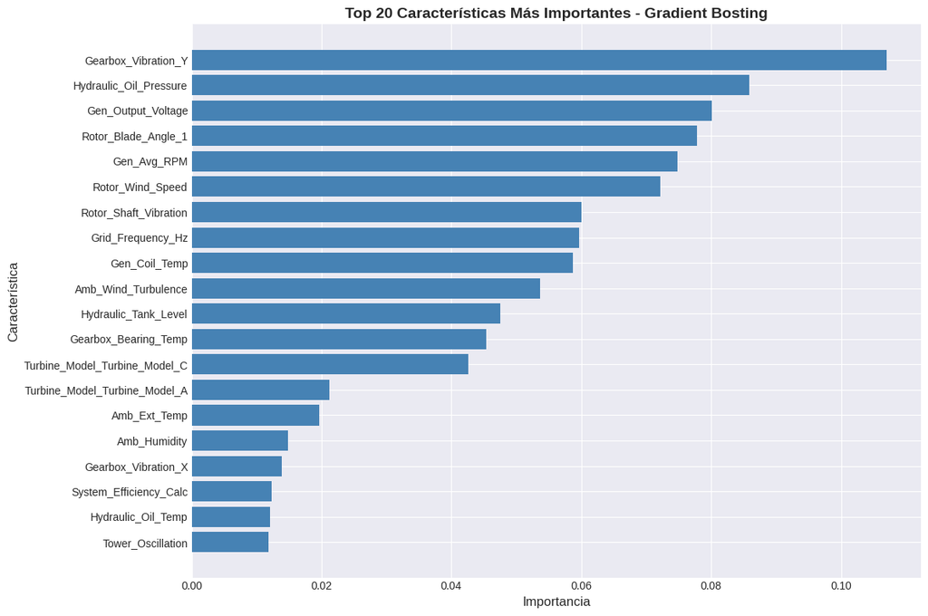

```python
# Evaluar el mejor modelo en el conjunto de prueba
best_bg = grid_bg.best_estimator_
y_pred_best = best_bg.predict(X_val_scaled)

print("EVALUACIÓN EN CONJUNTO DE VALIDACIÓN")
print(classification_report(y_val, y_pred_best, target_names=['Normal', 'Warning', 'Failure']))


print("IMPORTANCIA DE CARACTERÍSTICAS")
# Obtener importancia de características
feature_importance = pd.DataFrame({
    'feature': X_train_scaled.columns,
    'importance': best_bg.feature_importances_
}).sort_values('importance', ascending=False)
print(feature_importance.head(15).to_string(index=False))

# Gráfico de importancia de características
plt.figure(figsize=(12, 8))
top_features = feature_importance.head(20)
plt.barh(range(len(top_features)), top_features['importance'], color='steelblue')
plt.yticks(range(len(top_features)), top_features['feature'])
plt.xlabel('Importancia', fontsize=12)
plt.ylabel('Característica', fontsize=12)
plt.title('Top 20 Características Más Importantes - Gradient Bosting', fontsize=14, fontweight='bold')
plt.gca().invert_yaxis()
plt.tight_layout()
plt.show()
```

#### Análisis:

**USA TANTAS CELDAS COMO NECESITES**

### Análisis Crítico

Comparando este modelo con el anterior sí que tiene una mejora importante. Mejora en todos los aspectos de precision y recall, menos en recall de la clase Failure que lo igual, así, en la métrica del f1_score, que hemos dicho que era la más informativa mejora, tanto en macro como en weigthed gana en un 5% con un 80% y 83% respectivamente, valores bastante altos con poco margen de mejora.

## 5. Combinación secuencial de clasificadores de base diferente: Stacking (1.5 punto)

#### Implementación:

1. Implementa `StackingClassifier`.
2. Utiliza los modelos base implementados en la sección 2 ¿Crees que esta combinación de modelos es diversa y adecuada para Stacking?
3. Elige un meta-clasificador. Puedes optar por usar los hiperparámetros por defecto o realizar un pequeño ajuste si lo consideras necesario.
4. Valida el `StackingClassifier` completo usando los datos de validación con la métrica F1 seleccionada. Reporta el score.
5. **Análisis Crítico:** Compara el rendimiento de tu Stacking model con el mejor resultado que obtuviste de un ensemble individual (RF o Boosting) en los pasos anteriores. ¿Aportó Stacking una mejora significativa del rendimiento en este dataset? Explica brevemente cómo crees que el meta-clasificador está utilizando las predicciones de tus base learners elegidos.

#### Solución:

```python
base_learners = [ # Igual que en el apartado 2
    ('lr', LogisticRegression(
        max_iter=1000,
        class_weight='balanced',
        random_state=seed
    )),
    ('dt', DecisionTreeClassifier(
        max_depth=10,
        min_samples_leaf=5,
        random_state=seed
    )),
    ('knn', KNeighborsClassifier(
        n_neighbors=7,
        weights='distance'
    )),
    ('nb', GaussianNB())
]

meta_clf = LogisticRegression(
    C=0.5,
    max_iter=2000,
    class_weight='balanced',
    random_state=seed
)

# https://scikit-learn.org/stable/modules/generated/sklearn.ensemble.StackingClassifier.html
stacking = StackingClassifier(
    estimators=base_learners,
    final_estimator=meta_clf,
    cv=5,
    stack_method='predict_proba',
    n_jobs=-1
)

# Entrenamiento
stacking.fit(X_train_scaled, y_train)

# Predicción
y_pred_stack = stacking.predict(X_val_scaled)

# Evaluación
print("\nReporte de clasificación:")
print(classification_report(
    y_val, y_pred_stack,
    target_names=['Normal', 'Warning', 'Failure']
))
```

```
Reporte de clasificación:
              precision    recall  f1-score   support

      Normal       0.85      0.77      0.81       223
     Warning       0.69      0.79      0.74       136
     Failure       0.64      0.65      0.64        91

    accuracy                           0.75       450
   macro avg       0.73      0.74      0.73       450
weighted avg       0.76      0.75      0.75       450
```

#### Análisis:

**USA TANTAS CELDAS COMO NECESITES**

### Análisis Crítico

Este modelo tiene una buena precisión en la clase Normal pero algo mala en las clases de Failure y Warning. En el recall en cambio se mantiene bastante bien, consiguiendo, de entre todos los modelos el recall en la clase de Failure más alto, quizás la métrica más importante como se ha explicado más arriba.

En cuanto al f1_score vemos buenos valores, no comparabales a los dos últimos modelos vistos aunque si comparables al modelo de KNN teniendo valores similares.

En cuanto a cómo utiliza las predicciones el meta-clasificador, por el stack_method, el meta clasificador escogido y lo que he podido buscar funciona de la siguiente manera: Los modelos base, para cada dato exponen las probabilidades de las clases. Este dato lo clasifican como 10% Normal, 30% Warning y 60% Failure, por ejemplo, cada uno con unas probabilidades que ellos creen. El meta clasificador, al ver esto y otros análisis anteriores tiene que ver quién trabaja mejor en cada caso, este modelo trabaja mejor en este caso, este tiene una precisión mejor con esta clase... Con todo esto es que el meta clasificador elige finalmente qué clase asignar a cada dato.

## 6. Combinación secuencial de clasificadores de base diferente: Cascading (1.5 puntos)

#### Implementación:

1. Combina en cascada los modelos base implementados en la sección 2. Ten en cuenta la definición presentada en el documento "Combinación de models - PID_00296757, Jordi Casas Roma y Julià Minguillón Alfonso" que se encuentra en los recursos de la asignatura. Explora un Stacking con `passthrough=True` ¿Crees que esta combinación de modelos es diversa y adecuada para Cascading?
2. Elige un meta-clasificador. Puedes optar por usar los hiperparámetros por defecto o realizar un pequeño ajuste si lo consideras necesario.
3. Valida tu clasificador en cascada completo usando los datos de validación con la métrica seleccionada. Reporta el score.
4. **Análisis Crítico:** Compara el rendimiento de tu modelo en cascada con el mejor resultado obtenido en los pasos anteriores. ¿Aportó Cascading una mejora significativa del rendimiento en este dataset? ¿Observaste alguna ventaja en términos de eficiencia computacional?.

#### Solución:

```python
# La diferencia es el 'passthrough=True'.
# Esto concatena las predicciones de los modelos base con los datos originales (X) antes de enviárselos al Meta-Clasificador.
cascading = StackingClassifier(
    estimators=base_learners,
    final_estimator=meta_clf,
    cv=5,
    stack_method='predict_proba',
    passthrough=True,
    n_jobs=-1
)

# Entrenamiento
cascading.fit(X_train_scaled, y_train)

# Predicción
y_pred_cascade = cascading.predict(X_val_scaled)

# Evaluación
print("\nReporte de clasificación:")
print(classification_report(
    y_val, y_pred_cascade,
    target_names=['Normal', 'Warning', 'Failure']
))
```

```
Reporte de clasificación:
              precision    recall  f1-score   support

      Normal       0.85      0.76      0.80       223
     Warning       0.70      0.85      0.77       136
     Failure       0.68      0.66      0.67        91

    accuracy                           0.76       450
   macro avg       0.75      0.75      0.75       450
weighted avg       0.77      0.76      0.77       450
```

#### Análisis:

**USA TANTAS CELDAS COMO NECESITES**

### Análisis Crítico

Sí, esta es una buena combinación de modelos para el Cascading. Cada uno de los 4 modelos trabaja sobre fundamentos matemáticos diferentes.

- Logistic Regression: Dibuja una línea recta o plano para dividir datos. Es lineal.
- Decision Tree: Hace cajas y cortes cuadrados. Es no-lineal y jerárquico.
- KNN: Se basa en la cercanía de los vecinos. Es espacial.
- Naive Bayes: Se basa en probabilidades y estadística pura.

Mirando los resultado y comparandolo con Stacking sí que se puede ver alguna mejora aunque es muy pequeña. La precisión ha funcionado mejor en todos los casos menos en la clase Normal, que ha funcionado igual y el recall, en la clase Normal, está un 1% por debajo aunque bastante por encima en la clase de Warning. En general esto hace que, con las métricas f1_score se haya conseguido una mejor de un 2% tanto en macro como en weighted.

En cuanto a eficiencia computacional, al ser tiempo tan cortos, no he podido observar ninguna diferencia notable.

## 7. Alternativa: Balanced Random Forest (1 punto)

El BalancedRandomForestClassifier es una variante del algoritmo de ensamble Random Forest diseñada específicamente para abordar problemas de clasificación con clases severamente desbalanceadas sin necesidad de pre-procesamiento externo (como SMOTE).

Mecanismo de Funcionamiento: La diferencia fundamental respecto al Random Forest estándar reside en la etapa de construcción de cada árbol de decisión individual (proceso de bootstrapping):

Submuestreo Dinámico: Para entrenar cada árbol del bosque, el algoritmo genera un subconjunto de datos temporal. En este paso, realiza un submuestreo aleatorio (random undersampling) de la clase mayoritaria para igualar el número de instancias de la clase minoritaria.

Entrenamiento Equilibrado: Como resultado, cada árbol individual se entrena con un dataset perfectamente balanceado (ratio 1:1), aunque el dataset original esté descompensado.

Agregación: Finalmente, el modelo combina las predicciones de todos los árboles (que han visto diferentes subconjuntos equilibrados de la clase mayoritaria) mediante votación para generar la predicción final.

Ventaja Principal: Permite aprovechar la robustez del bagging (reducción de varianza) mientras mitiga el sesgo hacia la clase mayoritaria de forma nativa, explorando una mayor variedad de datos de la clase mayoritaria a través de los múltiples árboles.

#### Implementación:

1. Implementa `BalancedRandomForestClassifier` de la librería `imblearn`.
2. Entrena y valida el clasificador completo usando la métrica seleccionada. Reporta el score.
3. **Análisis Crítico:** Compara el rendimiento de este modelo con los anteriores. ¿dirías que este modelo es más "inteligente" o simplemente más "agresivo" disparando alarmas?.

#### Solución:

```python
# https://imbalanced-learn.org/stable/references/generated/imblearn.ensemble.BalancedRandomForestClassifier.html
brf = BalancedRandomForestClassifier(
    n_estimators=100,
    sampling_strategy='auto',
    replacement=False,       # Muestreo sin reemplazo
    random_state=42,
    n_jobs=-1
)

# Entrenamiento
print("Entrenando Balanced Random Forest...")
brf.fit(X_train_scaled, y_train)

# Predicción
y_pred_brf = brf.predict(X_val_scaled)

# Evaluación
print("\nReporte de clasificación:")
print(classification_report(
    y_val, y_pred_brf,
    target_names=['Normal', 'Warning', 'Failure']
))
```

```
Entrenando Balanced Random Forest...
```

```
Reporte de clasificación:
              precision    recall  f1-score   support

      Normal       0.89      0.78      0.83       223
     Warning       0.71      0.79      0.75       136
     Failure       0.63      0.70      0.66        91

    accuracy                           0.77       450
   macro avg       0.74      0.76      0.75       450
weighted avg       0.78      0.77      0.77       450
```

#### Análisis:

**USA TANTAS CELDAS COMO NECESITES**

### Análsis Crítico

Comparando este modelo directamente con el de RandomForest normal sí que podemos ver como este modelo es más "agresivo" sisparando alarmas. Esto porque podemos ver un recall bastante más alto, 70% frente a las 57% del RF y también vemos como baja la precisión de esta clase de un 63% actual frente a un 74% antes con que, con solo estos dos datos de esta clase sí que vemos com, intenta clasificar más datos como Failure, detecta más, sí, pero no siempre le sale bien.

## 8. Ajuste del Umbral de Decisión (1 punto)

#### Implementación:

Si tenemos en cuenta que la rotura de una turbina equivale a una pérdida de 50.000€ y que el coste de inspección de la turbina es de 200€, es preferible que el sistema active alarmas aunque algunas sean falsas a que ignore fallos reales. Por defecto, un clasificador decide que algo es un "Fallo" si la probabilidad calculada es mayor que el 50%. ¿Qué pasa si bajamos esa exigencia?

Con ayuda de cuaquier modelo de IA generativa, prioriza drásticamente la seguridad (Recall). Tu objetivo concreto es ajustar la lógica de decisión del modelo para alcanzar un Recall mínimo del 80% en la Clase 2 (Fallo Crítico).

Deberás pedirle a la IA que te explique cómo manipular el umbral de decisión (threshold) a partir de las probabilidades predichas para lograr este objetivo sin modificar el modelo ni reentrenarlo. Genera el nuevo reporte de clasificación y analiza: ¿A qué precio (en términos de Precisión) has conseguido esta seguridad?

#### Solución:

```python
# Seleccionamos el modelo a ajustar
modelo_seleccionado = grid_bg

# predict_proba nos devuelve una matriz de (n_muestras, 3_clases)
y_probs = modelo_seleccionado.predict_proba(X_test_scaled)

# La columna 2 corresponde a la clase Fallo
probs_failure = y_probs[:, 2]

# Función para aplicar un umbral personalizado en un problema multiclase
def apply_threshold(probs_matrix, threshold_failure):
    # Lógica: Si la probabilidad de fallo supera el umbral, predecimos Fallo (2).
    # Si no, predecimos la clase mayoritaria entre las otras dos (0 o 1).
    preds = []
    for i in range(len(probs_matrix)):
        if probs_matrix[i, 2] >= threshold_failure:
            preds.append(2) # Forzamos la predicción de Fallo
        else:
            # Si no es fallo, elegimos entre Normal (0) y Warning (1) según quién tenga más probabilidad
            preds.append(np.argmax(probs_matrix[i, :2]))
    return np.array(preds)

# Búsqueda iterativa del umbral para Recall >= 0.80
umb_optimo = 0.50
recall_obtenido = 0.0

# Bajamos el umbral de 0.01 en 0.01
for t in np.arange(0.50, 0.0, -0.01):
    y_temp = apply_threshold(y_probs, t)
    # Calculamos recall solo de la clase 2
    rec = recall_score(y_test, y_temp, labels=[2], average=None)[0]

    if rec >= 0.80:
        umb_optimo = t
        recall_obtenido = rec
        break

print(f"\nThreshold: {umb_optimo:.2f} (Predeterminado es 0.50)")
print(f"Recall alcanzado en clase Failure: {recall_obtenido:.4f}")


y_pred_safety = apply_threshold(y_probs, umb_optimo)

print("\n--- Reporte de Clasificación---")
print(classification_report(y_test, y_pred_safety, target_names=['Normal', 'Warning', 'Failure']))
```

```
Threshold: 0.04 (Predeterminado es 0.50)
Recall alcanzado en clase Failure: 0.8000

--- Reporte de Clasificación---
              precision    recall  f1-score   support

      Normal       0.91      0.75      0.82       224
     Warning       0.79      0.72      0.75       136
     Failure       0.51      0.80      0.62        90

    accuracy                           0.75       450
   macro avg       0.73      0.76      0.73       450
weighted avg       0.79      0.75      0.76       450
```

#### Análisis:

**USA TANTAS CELDAS COMO NECESITES**

Para este caso he utilizado el modelo que mejores resultados generales me ha dado a lo largo del Notebook, el Gradient Bosting. Comparando sus valores sí que vemos este recall esperado del 80% aunque con varias consecuencias.

La precisión en la clase Failure ha bajado de un 88% que teníamos antes hasta un 51%, valores que solo hemos visto en algún caso de los modelos base, sin embargo, esto ha afectado en las otras dos clases, ya que la clase Normal ha mejorado bastante la precisión y la clase Warning también ha conseguido mejorar, sin embargo, al subir estos valores de precisión y subir tanto el recall de la clase Failure vemos un descenso en un 16% en las otras dos clases.

Se podría decir que ahora, el modelo muchas más veces intenta clasificar a los datos como Failure, a no ser que está bastante seguro(precisión alta en Normal y Warning) de lo contrario, esto genera que muchos datos los clasifique mal(precisión baja en Failure) aunque encuentre bastantes datos que sí están en Failure(recall Failure), saltandose muchos datos de las otras clases(bajada imporante del recall en Normal y Warning)